# dsm data formatting example

‘Making sure your data is in the correct format for `dsm`.’

David L Miller http://distancesampling.org (CREEM, University of St Andrews)https://creem.st-andrews.ac.uk  
2020-05-06

# Introduction

The `dsm` package expects data to be in a certain format. In this example I’ll show how to get data into that format and give some explanation as to *why* each of these requirements exist.

I recommend getting to grips with fitting models in `dsm` before reading this tutorial so you know what the end point will look like before trying to grapple with the data. An example for [Gulf of Mexico pantropical spotted dolphins is available here](https://examples.distancesampling.org/dsm-line-dolphins/mexico-analysis.html).

# Overview

When we collect distance sampling data, we need to record the distance to an observation (along with other detectability covariates like weather), the transect we are currently on and how much effort we expended on that transect (its length or number of visits).

If we want to fit a DSM that information needs to be expanded to include where on the transect we are too, so we can build the spatial model. For point transects, this is simple as we are always at the point, but for line transects we need to know the position of the detection too (or equivalently, how far along the transect we are).

More abstractly, we need information about both detections and effort. We also need to link these two. In `dsm` we use three objects to hold this information:

- the fitted detection function (argument `ddf.obj`) holds all the detections but ignores spatial information
- the “segments” (argument `segment.data`) holds the chunks of effort (parts of the transect or point visits) and their locations. It might also include environmental covariate information.
- a table linking the above two (argument `observation.data`), making sure each detection has a corresponding segment that it was detected at.

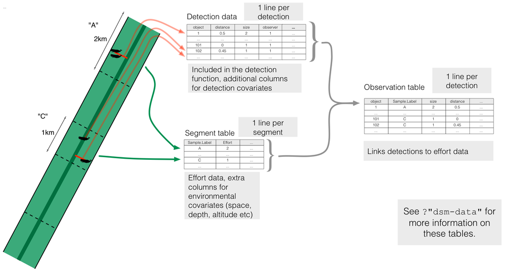

Correspondence between `dsm` tables

The above image gives an overview of how the different `data.frames` interact, along with how that corresponds to the real life situation of collecting data on a transect.

The rest of this example goes through each table in turn, explaining their construction.

# Table construction

## Detection data

The data requirements are very similar to those for packages `mrds` and `Distance`. In both cases each detection has a corresponding row. For an analysis using `dsm` we have additional requirements in the data (which can be auto-generated by `Distance` but we recommend against this to ensure that you know that records link up correctly).

For `Distance` we need:

- `distance` : the distance to the detection
- `object` : a unique detection identifier (which will link to the observation table)
- `size` : the number of individuals in the detection (1 if objects occur alone)

`mrds` requires the following extra columns (to allow for double observer surveys):

- `detected` : 1 if detected by the observer and 0 if missed (always 1 for single observer)
- `observer` : observer number (1 or 2) (always 1 for single observer)

If other covariates that affect detectability are recorder (like sex or weather) then these can be included in this data for analysis in `mrds` or `Distance`.

Once the model is fitted, we deal only with that fitted model object in the `dsm` analysis.

## Segment data

I will use the term “segment” here to refer to both points for point transects and small chunks of transect for the line transect case. I’ll assume that you’ve already segmented your lines while first describing the data format, then go on to an example of how to segment line transect data.

The `data.frame` required for the segments needs the following columns:

- `Effort` : the effort expended on this segment (either length of the segment for lines, or number of visits for points)
- `Sample.Label` : a unique identifier for the segment (if you are engaged in a complicated survey, this might take a format like “`YEAR`-`AREA`-`LINE`-`SEGMENT`”, so you have labels like “`2020-North-A-15`”, which can be useful to keep track of where data came from later).

In addition, environmental covariates like location and relevant covariates (sea surface temperature, foliage type, altitude, bathymetry etc) can be included in this `data.frame` if they are to be used in the spatial model.

### Segmenting

If you have data as lines and you want to chop them up into segments this section will give some sample R code to do this. How things work is extremely dependent on the input data, but hopefully this gives a template for what you want to do at least.

*Before you jump in*: If you are fluent in ArcGIS or QGIS I recommend doing this task in the software you are familiar with at first. A simple guide to doing this task in [QGIS is here](https://www.northrivergeographic.com/qgis-split-a-line-at-an-interval) and for [ArcGIS I recommend the MGET toolbox](https://mgel.env.duke.edu/mget/).

As an example, we will look at an aerial survey of seabirds off the coast of Rhode Island, USA. Data from these surveys were collected by the University of Rhode Island and analysed in Winiarski, Miller, Paton, & McWilliams (2013), K. J. Winiarski, Burt, et al. (2014) and K. J. Winiarski et al. (2014). I have the transects saved as a shapefile that I will then “chop-up” into segments. To start with let’s plot the data with the coastline:

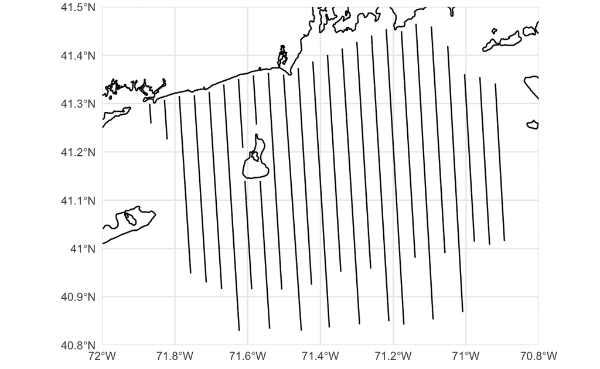

```r
library(ggplot2)
library(sf)

# coast data, just for reference
coastline <- read_sf("data/ri_coast.shp")

# our transect lines
transects <- read_sf("data/ri_transects.shp")

# now make the plot
p <- ggplot() +
  # geom_sf knows what to do with spatial data
  geom_sf(data=coastline) +
  geom_sf(data=transects) +
  # chop to be on a better scale
  coord_sf(xlim=c(-72, -70.8), ylim=c(40.8, 41.5), expand=FALSE) +
  # make the plot look simpler
  theme_minimal()
print(p)
```

In the above code we have loaded the `sf` package. This is the package we will use to do most of our spatial work in segmenting the data. It has most of the tools that modern a GIS has, though the package is still being developed so its functionality is increasing all the time.

Investigating the `transects` data we loaded, we can see it consists of a `data.frame` with some extra bits (the spatial information, including locations (`geometry`) and projection (`CRS`)):

```r
transects
```

```
Simple feature collection with 508 features and 1 field
geometry type:  LINESTRING
dimension:      XY
bbox:           xmin: -71.86948 ymin: 40.82944 xmax: -70.8944 ymax: 41.46521
CRS:            4326
# A tibble: 508 x 2
   Transect                                 geometry
      <dbl>                         <LINESTRING [°]>
 1        1  (-71.86764 41.2793, -71.86581 41.25891)
 2        1  (-71.86948 41.29969, -71.86764 41.2793)
 3        2   (-71.82327 41.2462, -71.82145 41.2258)
 4        2  (-71.82872 41.30738, -71.8269 41.28698)
 5        2  (-71.82508 41.26659, -71.82327 41.2462)
 6        2  (-71.8269 41.28698, -71.82508 41.26659)
 7        3 (-71.75849 40.96885, -71.75676 40.94846)
 8        3 (-71.76022 40.98925, -71.75849 40.96885)
 9        3 (-71.76195 41.00965, -71.76022 40.98925)
10        3 (-71.77062 41.11164, -71.76888 41.09124)
# … with 498 more rows
```

This data looks in good shape, so we can use the `st_segmentize` function to take each transect and make segments from them.

```r
segs <- st_segmentize(transects, dfMaxLength=units::set_units(2000, m))
```

Here we know the truncation used for the detection function was 1000m (the distances were collected in bins and this was the further bin), and since we’re trying to make our segments approximately square, we set the length to be twice that (since the truncation applies to either side of the transect), so 2000m.

Looking at what that did:

```r
segs
```

```
Simple feature collection with 508 features and 1 field
geometry type:  LINESTRING
dimension:      XY
bbox:           xmin: -71.86948 ymin: 40.82944 xmax: -70.8944 ymax: 41.46521
CRS:            4326
# A tibble: 508 x 2
   Transect                                                   geometry
      <dbl>                                           <LINESTRING [°]>
 1        1 (-71.86764 41.2793, -71.86673 41.2691, -71.86581 41.25891)
 2        1 (-71.86948 41.29969, -71.86856 41.2895, -71.86764 41.2793)
 3        2   (-71.82327 41.2462, -71.82236 41.236, -71.82145 41.2258)
 4        2 (-71.82872 41.30738, -71.82781 41.29718, -71.8269 41.2869…
 5        2 (-71.82508 41.26659, -71.82418 41.25639, -71.82327 41.246…
 6        2 (-71.8269 41.28698, -71.82599 41.27679, -71.82508 41.2665…
 7        3 (-71.75849 40.96885, -71.75762 40.95865, -71.75676 40.948…
 8        3 (-71.76022 40.98925, -71.75935 40.97905, -71.75849 40.968…
 9        3 (-71.76195 41.00965, -71.76108 40.99945, -71.76022 40.989…
10        3 (-71.77062 41.11164, -71.76975 41.10144, -71.76888 41.091…
# … with 498 more rows
```

We now have 508 segments each about 2km long. We can check the lengths using the `st_length` function and plot a histogram of the segment lengths:

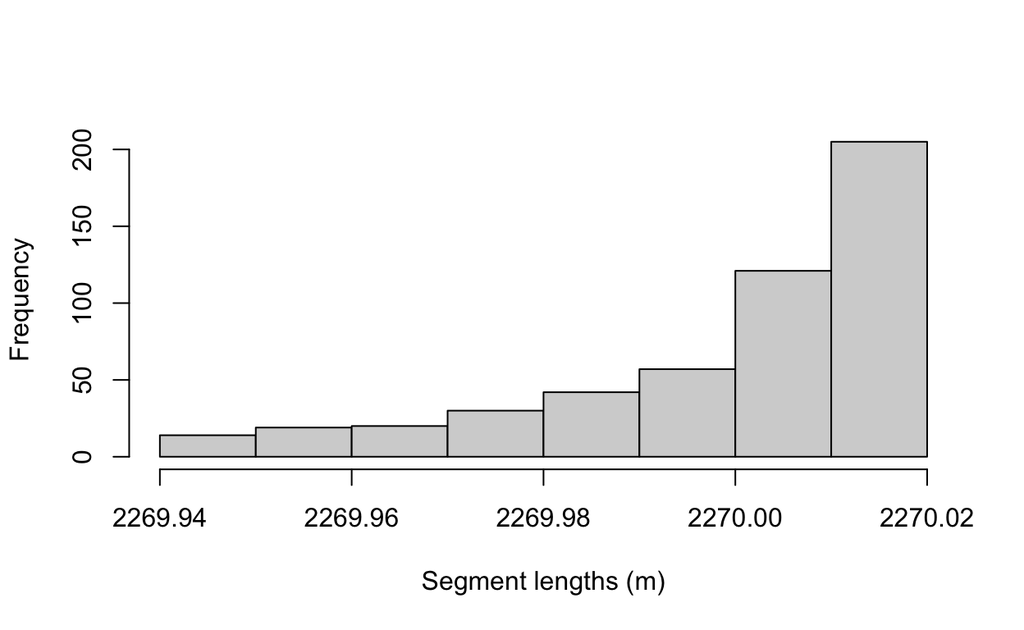

```r
hist(st_length(segs), xlab="Segment lengths (m)", main="")
```

Note that in setting the `dfMaxLength` argument to `st_segmentize` we are giving a rough guide to the segment length and the algorithm inside `st_segmentize` tries to get segments to be as equal in length as possible (note the $x$ axis in the histogram).

Note that the `Transect` column in `segs` now has duplicate entries as each transect has multiple segments in it. We can now create our required columns for `dsm`.

First the `Effort` column can be generated using `st_length`:

```r
segs$Effort <- st_length(segs)
```

Then we can generate the `Sample.Labels`. Here I’ll use a more complicated naming scheme to show how that’s done, but one could simply write `segs$Sample.Label <- 1:nrow(segs)` and that would be sufficient. Instead, I would like to have my `Sample.Label` be the “`YEAR`-`AREA`-`LINE`-`SEGMENT`” scheme I suggested above.

There are fancier ways to do this, but for clarity, let’s use a `for` loop:

```r
# create a dummy column that we can fill-in as we go
segs$Sample.Label <- NA

# set the year and area once for this data
year <- 2010
area <- "RI"

# loop over the transect IDs
for(this_transect in unique(segs$Transect)){
  # how many segments in this transect?
  n_segs <- nrow(subset(segs, Transect==this_transect))
  # generate the n_segs labels that we need
  segs$Sample.Label[segs$Transect==this_transect] <- paste(year, area, this_transect,
                                                           1:n_segs, sep="-")
}
```

Now we can check that looks right:

```r
segs
```

```
Simple feature collection with 508 features and 3 fields
geometry type:  LINESTRING
dimension:      XY
bbox:           xmin: -71.86948 ymin: 40.82944 xmax: -70.8944 ymax: 41.46521
CRS:            4326
# A tibble: 508 x 4
   Transect                             geometry   Effort Sample.Label
      <dbl>                     <LINESTRING [°]>      [m] <chr>
 1        1 (-71.86764 41.2793, -71.86673 41.26… 2269.990 2010-RI-1-1
 2        1 (-71.86948 41.29969, -71.86856 41.2… 2269.990 2010-RI-1-2
 3        2 (-71.82327 41.2462, -71.82236 41.23… 2269.996 2010-RI-2-1
 4        2 (-71.82872 41.30738, -71.82781 41.2… 2269.996 2010-RI-2-2
 5        2 (-71.82508 41.26659, -71.82418 41.2… 2269.996 2010-RI-2-3
 6        2 (-71.8269 41.28698, -71.82599 41.27… 2269.996 2010-RI-2-4
 7        3 (-71.75849 40.96885, -71.75762 40.9… 2270.004 2010-RI-3-1
 8        3 (-71.76022 40.98925, -71.75935 40.9… 2270.003 2010-RI-3-2
 9        3 (-71.76195 41.00965, -71.76108 40.9… 2270.003 2010-RI-3-3
10        3 (-71.77062 41.11164, -71.76975 41.1… 2270.002 2010-RI-3-4
# … with 498 more rows
```

With the required columns taken care of, we can also calculate the centroids of our segments to get the locations of each segment to use in the spatial model. Handily we can use `st_centroid` to do this in one step and keep all our data at the same time:

```r
segs <- st_centroid(segs)
segs
```

```
Simple feature collection with 508 features and 3 fields
geometry type:  POINT
dimension:      XY
bbox:           xmin: -71.86856 ymin: 40.83964 xmax: -70.89518 ymax: 41.45501
CRS:            4326
# A tibble: 508 x 4
   Transect             geometry   Effort Sample.Label
      <dbl>          <POINT [°]>      [m] <chr>
 1        1  (-71.86673 41.2691) 2269.990 2010-RI-1-1
 2        1  (-71.86856 41.2895) 2269.990 2010-RI-1-2
 3        2   (-71.82236 41.236) 2269.996 2010-RI-2-1
 4        2 (-71.82781 41.29718) 2269.996 2010-RI-2-2
 5        2 (-71.82418 41.25639) 2269.996 2010-RI-2-3
 6        2 (-71.82599 41.27679) 2269.996 2010-RI-2-4
 7        3 (-71.75762 40.95865) 2270.004 2010-RI-3-1
 8        3 (-71.75935 40.97905) 2270.003 2010-RI-3-2
 9        3 (-71.76108 40.99945) 2270.003 2010-RI-3-3
10        3 (-71.76975 41.10144) 2270.002 2010-RI-3-4
# … with 498 more rows
```

Notice that our `geometry type` is now `POINT`. We can plot these centroids on our previous map:

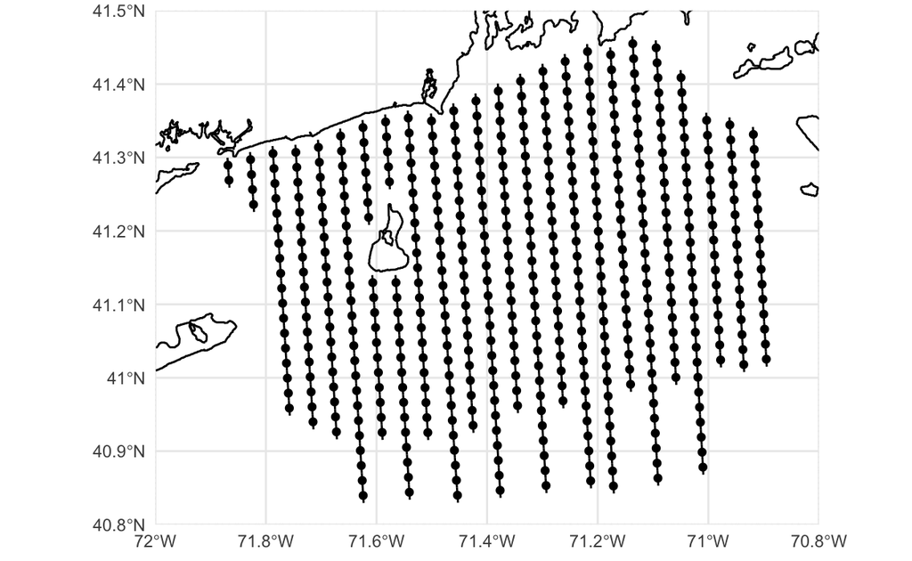

```r
p <- ggplot() +
  # geom_sf knows what to do with spatial data
  geom_sf(data=coastline) +
  geom_sf(data=transects) +
  geom_sf(data=segs) +
  # chop to be on a better scale
  coord_sf(xlim=c(-72, -70.8), ylim=c(40.8, 41.5), expand=FALSE) +
  # make the plot look simpler
  theme_minimal()
print(p)
```

Finally, at the moment the `dsm` package doesn’t know how to talk to `sf` objects, so we need to simplify `segs` to be a regular `data.frame`. We can extract the coordinates of the centroids using `st_coordinates` and then append them onto a `data.frame` version of the object with the geometry dropped like so:

```r
segs_df <- cbind(as.data.frame(st_drop_geometry(segs)),
              st_coordinates(segs))
```

We can double check that looks right:

```r
head(segs_df)
```

```
  Transect       Effort Sample.Label         X        Y
1        1 2269.990 [m]  2010-RI-1-1 -71.86673 41.26910
2        1 2269.990 [m]  2010-RI-1-2 -71.86856 41.28950
3        2 2269.996 [m]  2010-RI-2-1 -71.82236 41.23600
4        2 2269.996 [m]  2010-RI-2-2 -71.82781 41.29718
5        2 2269.996 [m]  2010-RI-2-3 -71.82418 41.25639
6        2 2269.996 [m]  2010-RI-2-4 -71.82599 41.27679
```

and we are done. See the next section for how to link the segments and the detections.

If we want to include spatial covariate information in the segment table, we could then use (for example) [`rerrdap`](https://CRAN.R-project.org/package=rerddap) to obtain remotely-sensed data. For *in situ* data (i.e., weather conditions recorded while on effort), this can be more complicated and will require the use of `summarize`, see [this thread for more information](https://github.com/r-spatial/sf/issues/321) on how to deal with this situation.

## Linking observations and segments

To link together the data in the detection function and the spatial data giving the effort we use the observation `data.frame`. This is really just a cross-reference between those two tables, so each detection lives in one segment.

The observation `data.frame` must have (at least) the following columns:

- `object` : unique object identifier (corresponding to those identifiers in the detection function)
- `Sample.Label` : the identifier for the segment that the observation occurred in
- `size` : the size of each observed group (e.g 1 if all animals occurred individually)
- `distance` : distance to observation

The observation data should have as many rows as there are in the detection function.

### Relating observations and segments in practice

There are a few methods for building the observation table. Here I’ll illustrate one assigning detections to segments based on their distance (detections are associated with their closest segment centroid). This is appropriate when you don’t see forwards too far, so it’s unlikely that detections will be miss assigned. This is true in an aerial survey case where observers look our of side windows of the plane but might be inappropriate for a shipboard survey where observers on the flying bridge can see way ahead of the ship.

First loading the detection data for this survey (this would be what we use to fit the detection function, post processing):

```r
obs <- read.csv("data/loons.csv")
head(obs)
```

```
        Date     Time Bin      Lat      Long Observer object size
1 2011-04-19 18991230   B 40.85296 -71.45511       JV     46    1
2 2011-02-17 18991230   A 40.87022 -71.54842       JV    106    1
3 2011-05-02 18991230   A 40.87595 -71.30304       KW    121    1
4 2011-12-04 18991230   C 40.91753 -71.38273       KW    286    1
5 2011-02-23 18991230   A 40.94153 -71.38517       KW    446    1
6 2011-02-07 18991230   A 40.94225 -71.46438       KW    457    1
```

We can see there are columns for latitude and longitude (`Lat` and `Long`). We can make this `data.frame` be an `sf` object by telling `sf` that these columns contain geometry information:

```r
obs <- st_as_sf(obs, coords=c("Long", "Lat"))
# set the coordinate system
st_crs(obs) <- 4326
obs
```

```
Simple feature collection with 941 features and 6 fields
geometry type:  POINT
dimension:      XY
bbox:           xmin: -71.86962 ymin: 40.85296 xmax: -70.89175 ymax: 41.46472
CRS:            EPSG:4326
First 10 features:
         Date     Time Bin Observer object size
1  2011-04-19 18991230   B       JV     46    1
2  2011-02-17 18991230   A       JV    106    1
3  2011-05-02 18991230   A       KW    121    1
4  2011-12-04 18991230   C       KW    286    1
5  2011-02-23 18991230   A       KW    446    1
6  2011-02-07 18991230   A       KW    457    1
7  2011-04-19 18991230   A       JV    500    2
8  2011-05-02 18991230   A       KW    506    1
9  2011-02-23 18991230   B       JV    814    1
10 2011-04-19 18991230   A       KW    911    1
                     geometry
1  POINT (-71.45511 40.85296)
2  POINT (-71.54842 40.87022)
3  POINT (-71.30304 40.87595)
4  POINT (-71.38273 40.91753)
5  POINT (-71.38517 40.94153)
6  POINT (-71.46438 40.94225)
7  POINT (-71.59495 40.94761)
8    POINT (-71.552 40.94795)
9  POINT (-71.51172 40.97912)
10 POINT (-71.59762 40.98571)
```

We can overlay this on our previous map of transects:

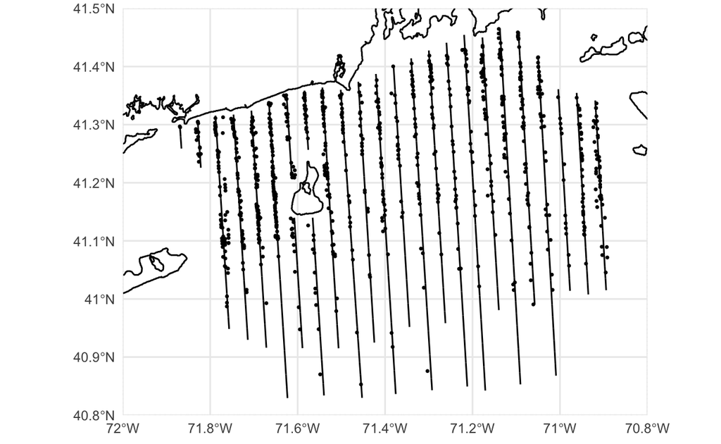

```r
p <- ggplot() +
  # geom_sf knows what to do with spatial data
  geom_sf(data=coastline) +
  geom_sf(data=transects) +
  geom_sf(data=obs, size=0.5) +
  # chop to be on a better scale
  coord_sf(xlim=c(-72, -70.8), ylim=c(40.8, 41.5), expand=FALSE) +
  # make the plot look simpler
  theme_minimal()
print(p)
```

Going back to our `segs` object above, we can use the `st_join` function, using the `st_nearest_feature` function to control when the tables are linked:

```r
obs <- st_join(obs, segs, join=st_nearest_feature)
obs
```

```
Simple feature collection with 941 features and 9 fields
geometry type:  POINT
dimension:      XY
bbox:           xmin: -71.86962 ymin: 40.85296 xmax: -70.89175 ymax: 41.46472
CRS:            EPSG:4326
First 10 features:
         Date     Time Bin Observer object size Transect       Effort
1  2011-04-19 18991230   B       JV     46    1       10 2270.016 [m]
2  2011-02-17 18991230   A       JV    106    1        8 2270.016 [m]
3  2011-05-02 18991230   A       KW    121    1       14 2270.008 [m]
4  2011-12-04 18991230   C       KW    286    1       12 2270.014 [m]
5  2011-02-23 18991230   A       KW    446    1       12 2270.014 [m]
6  2011-02-07 18991230   A       KW    457    1       10 2270.016 [m]
7  2011-04-19 18991230   A       JV    500    2        7 2270.015 [m]
8  2011-05-02 18991230   A       KW    506    1        8 2270.016 [m]
9  2011-02-23 18991230   B       JV    814    1        9 2270.017 [m]
10 2011-04-19 18991230   A       KW    911    1        7 2270.015 [m]
   Sample.Label                   geometry
1  2010-RI-10-2 POINT (-71.45511 40.85296)
2   2010-RI-8-2 POINT (-71.54842 40.87022)
3  2010-RI-14-2 POINT (-71.30304 40.87595)
4  2010-RI-12-6 POINT (-71.38273 40.91753)
5  2010-RI-12-4 POINT (-71.38517 40.94153)
6  2010-RI-10-4 POINT (-71.46438 40.94225)
7   2010-RI-7-2 POINT (-71.59495 40.94761)
8   2010-RI-8-4   POINT (-71.552 40.94795)
9  2010-RI-9-10 POINT (-71.51172 40.97912)
10  2010-RI-7-8 POINT (-71.59762 40.98571)
```

Now `obs` has acquired additional columns from `segs`, including the `Sample.Label` (which we want) and `Effort` (which we don’t). To check this worked okay, we can plot the `obs` and `segs` with colour coding for the `Sample.Label`. I randomized the colour order so it would be easier to tell if observations were misallocated.

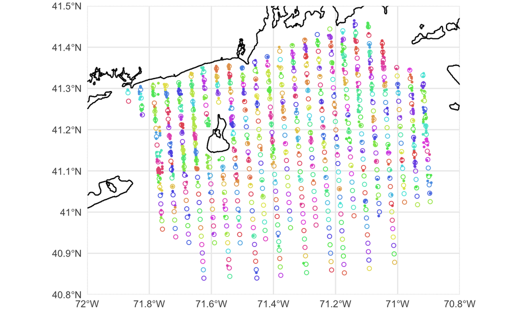

```r
# make a random colour palette to avoid similar colours being near each other
pal <- rainbow(nrow(segs), s=.6, v=.9)[sample(1:nrow(segs),nrow(segs))]
p <- ggplot() +
  # geom_sf knows what to do with spatial data
  geom_sf(data=coastline) +
  geom_sf(data=segs, aes(colour=Sample.Label), pch=21) +
  geom_sf(data=obs, size=0.5, aes(colour=Sample.Label)) +
  # chop to be on a better scale
  coord_sf(xlim=c(-72, -70.8), ylim=c(40.8, 41.5), expand=FALSE) +
  scale_colour_manual(values=pal) +
  # make the plot look simpler
  theme_minimal() +
  theme(legend.position = "none")
print(p)
```

As with `segs` we can remove unnecessary columns and geometry to get the required columns only:

```r
# get rid of "spatialness"
obs <- st_drop_geometry(obs)
# select the columns we need
obs <- obs[, c("object", "Sample.Label", "size", "Bin")]
head(obs)
```

```
  object Sample.Label size Bin
1     46 2010-RI-10-2    1   B
2    106  2010-RI-8-2    1   A
3    121 2010-RI-14-2    1   A
4    286 2010-RI-12-6    1   C
5    446 2010-RI-12-4    1   A
6    457 2010-RI-10-4    1   A
```

(Note here since we have binned data, we just keep the `Bin` column and need to process this further later.)

A different way to approach this would be if there were timestamps on waypoints from the GPS, which could be related to the segments. One could then look at whether an observation was made between the start and end times of a segment.

# More information

This information is summarized at `?"dsm-data"` in the `dsm` package. It may also be useful to look at the data in the example dataset `mexdolphins` which can be loaded with `data(mexdolphins)`. The vignette for an analysis of those data [is available here](https://examples.distancesampling.org/dsm-line-dolphins/mexico-analysis.html).

It’s hard to give very general information on how to segment lines, as to some extent it depends on how the data were originally formatted (going all the way back to the make and model of the GPS unit used). More information on dealing with spatial data in R using the `sf` package is available at [the R spatial website](https://r-spatial.github.io/sf/) (see the “Articles” drop down in the header).

Winiarski, K. J., Burt, M. L., Rexstad, E., Miller, D. L., Trocki, C. L., Paton, P. W. C., & McWilliams, S. R. (2014). Integrating aerial and ship surveys of marine birds into a combined density surface model: A case study of wintering Common Loons. *The Condor*, *116*(2), 149–161. https://doi.org/10.1650/CONDOR-13-085.1

Winiarski, K. J., Miller, D. L., Paton, P. W. C., & McWilliams, S. R. (2014). A spatial conservation prioritization approach for protecting marine birds given proposed offshore wind energy development. *Biological Conservation*, *169*, 79–88. https://doi.org/10.1016/j.biocon.2013.11.004

Winiarski, K., Miller, D., Paton, P., & McWilliams, S. (2013). Spatially explicit model of wintering common loons: Conservation implications. *Marine Ecology Progress Series*, *492*, 273–283. https://doi.org/10.3354/meps10492